# Multiple Hypothesis Testig

Bios 221: Modern Statistics for Modern Biology

7/5/2018

## Goal

In this lab, we will become familiar with count data in RNA-Seq high-throughput sequencing. We will see how tools developed during the lecture on hypothesis testing can be applied to data from RNA-Seq experiments. We will model counts data and evaluate model fits to detect and quantify systematic changes between conditions, compared to within-condition variability (which we consider noise).

## Load Packages

Install packages.

```r
pkgs_needed = c("dplyr","ggplot2", "DESeq2","pasilla","genefilter",
                "pheatmap","readr","tibble","apeglm")
if (!requireNamespace("BiocManager", quietly = TRUE))
    install.packages("BiocManager")
BiocManager::install(setdiff(pkgs_needed, installed.packages()))
```

Load packages.

```r
library("dplyr")
library("ggplot2")
library("DESeq2")
library("pasilla")
library("genefilter")
library("pheatmap")
library("tibble")
```

## Example dataset: the pasilla data

The `pasilla` data are from an experiment on Drosophila melanogaster cell cultures that investigated the effect of RNAi knock-down of the splicing factor on the cells' transcriptome. Let us load an example dataset. It resides in the experiment data package `pasilla`. We already quickly explored this dataset in our lab on variance stabilizing transformations.

```r
fn = system.file("extdata", "pasilla_gene_counts.tsv",
                  package = "pasilla", mustWork = TRUE)
counts = as.matrix(read.csv(fn, sep = "\t", row.names = "gene_id"))
```

The data are stored as a rectangular table in a tab-delimited file, which we've read into the matrix `counts`.

```r
dim(counts)
```

```
## [1] 14599     7
```

```r
counts[ 2000+(0:3), ]
```

```
##             untreated1 untreated2 untreated3 untreated4 treated1 treated2
## FBgn0020369       3387       4295       1315       1853     4884     2133
## FBgn0020370       3186       4305       1824       2094     3525     1973
## FBgn0020371          1          0          1          1        1        0
## FBgn0020372         38         84         29         28       63       28
##             treated3
## FBgn0020369     2165
## FBgn0020370     2120
## FBgn0020371        0
## FBgn0020372       27
```

When loading data from a file, a good plausibility check is to print out some of the data, and maybe not only at the very beginning, but also at some random point in the middle, as we have done above. The table is a matrix of integer values: the value in the $i$th row and the $j$th column of the matrix indicates how many reads have been mapped to gene $i$ in sample $j$.

There were two experimental conditions, termed **untreated** and **treated** in the header of the count table that we loaded. They correspond to negative control and to siRNA against `pasilla`. The experimental metadata of the 7 samples in this dataset are provided in a spreadsheet-like table. Here, we use the function `system.file` to locate a file that is shipped together with the `pasilla` package. When you work with your own data, simply prepare and load the corresponding file, or use some other way to generate a dataframe like `pasillaSampleAnnoand`.

```r
annotationFile = system.file("extdata", "pasilla_sample_annotation.csv",
                             package = "pasilla", mustWork = TRUE)
pasillaSampleAnno = readr::read_csv(annotationFile)
pasillaSampleAnno
```

```
## # A tibble: 7 x 6
##   file     condition type     `number of lane… `total number of r… `exon counts`
##   <chr>    <chr>     <chr>               <dbl> <chr>                       <dbl>
## 1 treated… treated   single-…                5 35158667                 15679615
## 2 treated… treated   paired-…                2 12242535 (x2)            15620018
## 3 treated… treated   paired-…                2 12443664 (x2)            12733865
## 4 untreat… untreated single-…                2 17812866                 14924838
## 5 untreat… untreated single-…                6 34284521                 20764558
## 6 untreat… untreated paired-…                2 10542625 (x2)            10283129
## 7 untreat… untreated paired-…                2 12214974 (x2)            11653031
```

As we see here, the overall dataset was produced in two batches, the first one consisting of three sequencing libraries that were subjected to single-read sequencing, the second batch consisting of four libraries for which paired-end sequencing was used. Let's convert the relevant columns of `pasillaSampleAnno` into factors, overriding the default level ordering (which is alphabetical) by one that makes more sense to us.

```r
pasillaSampleAnno = mutate(
  pasillaSampleAnno,
  condition = factor(condition, levels = c("untreated", "treated")),
  type      = factor(type, levels = c("single-read", "paired-end")))
```

The design is approximately balanced between the factor of interest, `condition`, and the nuisance factor `type`. How can you check that? Use the `table` function.

```r
# TODO
```

We use the constructor function `DESeqDataSetFromMatrix` to create a `DESeqDataSet` from the matrix `counts` and the sample annotation dataframe `pasillaSampleAnno`.

Note how in the code below, we have to put in extra work to match the column names of the `counts` object with the `file` column of the `pasillaSampleAnno` dataframe, in particular, we need to remove the `fb` that happens to be used in the `file` column for some reason. Such data wrangling is very common. One of the reasons for storing the data in a `DESeqDataSet` object is that we then no longer have to worry about such things.

```r
mt = match(colnames(counts), sub("fb$", "", pasillaSampleAnno$file))
pasilla = DESeqDataSetFromMatrix(
  countData = counts,
  colData   = pasillaSampleAnno[mt, ],
  design    = ~ condition)
class(pasilla)
```

```
## [1] "DESeqDataSet"
## attr(,"package")
## [1] "DESeq2"
```

```r
is(pasilla, "SummarizedExperiment")
```

```
## [1] TRUE
```

The `SummarizedExperiment` class --and therefore `DESeqDataSet`-- also contains facilities for storing annotation of the rows of the count matrix. For now, we are content with the gene identifiers from the row names of the `counts` table.

**Quiz Question 1**: When we constructed our `SummarizedExperiment` object, we also saved some column metadata which we had initially stored in `pasillaSampleAnno`. With which function can we extract this information again? (Hint:`?SummarizedExperiment`)

It will be instructive to quickly redo the analysis we did in a previous lab on the mean-variance relationship for the biological replicates in the pasilla dataset using the `log` scale on both axes:

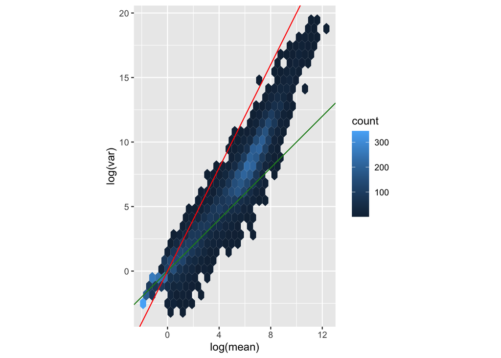

```r
library("ggplot2")
library("matrixStats")
sf = estimateSizeFactorsForMatrix(counts)
ncounts  = counts / matrix(sf,
   byrow = TRUE, ncol = ncol(counts), nrow = nrow(counts))
uncounts = ncounts[, grep("^untreated", colnames(ncounts)), drop = FALSE]

# TODO: fill in ... with row means and row variances of the uncounts matrix
p = ggplot(
  tibble(mean = apply(uncounts, 1, mean), var = apply(uncounts, 1, var)),
         aes(x = log(mean), y = log(var))) +
  geom_hex() +
  coord_fixed() +
  geom_abline(slope = 1:2, color = c("forestgreen", "red"))
p
```

The green line (slope 1) is what we expect if the variance ($v$) equals the mean ($m$), as is the case for a Poisson-distributed random variable: $v=m$. We see that this approximately fits the data in the lower range. The red line (slope 2) corresponds to the quadratic mean-variance relationship $v=m^2$; lines parallel to it (not shown) would represent $v = cm^2$ for various values of $c$. We can see that in the upper range of the data, the quadratic relationship approximately fits the data, for some value of $c<1$.

## Size factors

In class we showed a plot comparing the slightly more refined method employed by DESeq2 for estimating size factors, compared to just summing the total number of counts in a sample across all genes. Let us directly do this:

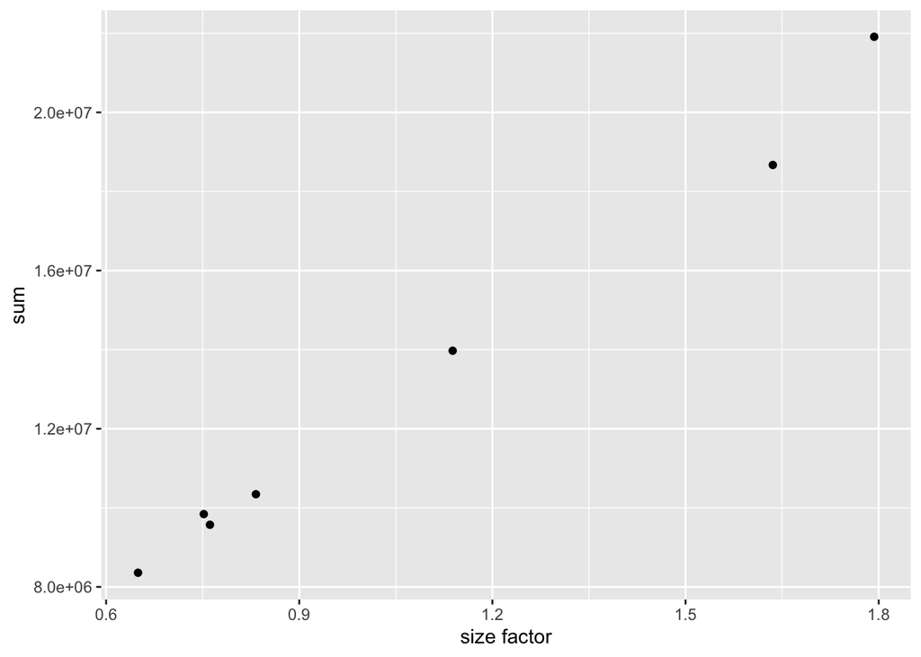

```r
ggplot(tibble(
  `size factor` = estimateSizeFactorsForMatrix(counts),
  `sum` = colSums(counts)), aes(x = `size factor`, y = `sum`)) +
  geom_point()
```

## The DESeq2 method

After these preparations, we are now ready to jump straight into differential expression analysis. A choice of standard analysis steps are wrapped into a single function, `DESeq`.

```r
pasilla = DESeq(pasilla)
```

The DESeq function is simply a wrapper that calls, in order, the functions `estimateSizeFactors`, `estimateDispersions` (dispersion estimation) and `nbinomWaldTest` (hypothesis tests for differential abundance). You can always call these functions individually if you want to modify their behavior or interject custom steps. Let us look at the results.

```r
res = results(pasilla)
res[order(res$padj), ] %>% head
```

```
## log2 fold change (MLE): condition treated vs untreated
## Wald test p-value: condition treated vs untreated
## DataFrame with 6 rows and 6 columns
##                     baseMean    log2FoldChange              lfcSE
##                    <numeric>         <numeric>          <numeric>
## FBgn0039155 730.595806139728 -4.61901333325316  0.168706777691263
## FBgn0025111 1501.41051323996  2.89986434281464  0.126920536499104
## FBgn0029167 3706.11653071978 -2.19700018176299 0.0969888426793355
## FBgn0003360 4343.03539692487 -3.17967219633152  0.143526399548808
## FBgn0035085 638.232608936723 -2.56041189472443  0.137295200724247
## FBgn0039827 261.916235943103 -4.16251579404328  0.232588799612089
##                          stat                pvalue                  padj
##                     <numeric>             <numeric>             <numeric>
## FBgn0039155 -27.3789434927507 4.88598917049146e-165 4.06660878660004e-161
## FBgn0025111  22.8478733450288 1.53429589608622e-115 6.38497237156281e-112
## FBgn0029167 -22.6520919424383 1.33042414468249e-113 3.69104005206412e-110
## FBgn0003360 -22.1539187656569 9.56283102522569e-109 1.98978606557384e-105
## FBgn0035085 -18.6489540873823  1.28771779124823e-77  2.14353503531181e-74
## FBgn0039827 -17.8964584751523  1.25663334671151e-71  1.74315989077998e-68
```

The first step after a differential expression analysis is visualization of the results.

### Histogram of p-values

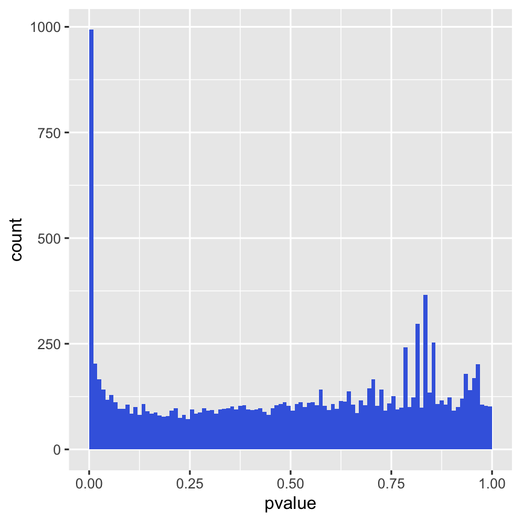

```r
ggplot(as(res, "data.frame"), aes(x = pvalue)) +
  geom_histogram(binwidth = 0.01, fill = "Royalblue", boundary = 0)
```

The distribution displays two main components: a uniform background with values between 0 and 1, and a peak of small p-values at the left. The uniform background corresponds to the non-differentially expressed genes. Usually this is the majority of genes. The left hand peak corresponds to differentially bioexpressed genes.

The ratio of the level of the background to the height of the peak gives us a rough indication of the false discovery rate (FDR) that would be associated with calling the genes in the leftmost bin differentially expressed.

**Quiz Question 2**: What is the FDR (in %) for the leftmost bin (i.e. when rejecting hypotheses smaller than 0.01)? The code snippet below might be a good starting point. Estimate the background level with the median bin count in the histogram object.

```r
pv_hist <- hist(res$pvalue, breaks=seq(0,1, length=100), plot=FALSE)
```

Recall from class the we can use `p.adjust` function to conduct multiple testing directly on the p-values (and we reject the adjusted p-values $\leq \alpha$). Let us quickly extract the p-values and remove the NAs:

```r
pvals <- na.omit(res$pvalue)
```

**Quiz Question 3**: How many p-values are <= 0.1?

**Quiz Question 4**: How many hypotheses do you reject with Benjamini-Hochberg at a FDR of 0.1?

**Quiz Question 5**: How many hypotheses do you reject with Bonferroni at a FWER of 0.1?

You might notice that your answer to 4 is different than what the adjusted p-values in `res$padj` might imply; the reason is that internally DESeq2 uses a more advanced method to do the FDR correction compared to Benjamini-Hochberg (a simplified variant of IHW in which low counts genes get filtered out).

As mentioned in the testing class, we can use the p-value histogram plot for diagnostic purposes. Let's look at a simulation to understand this point. First, we simulate four samples under the null (same mean and variance) and apply t-tests:

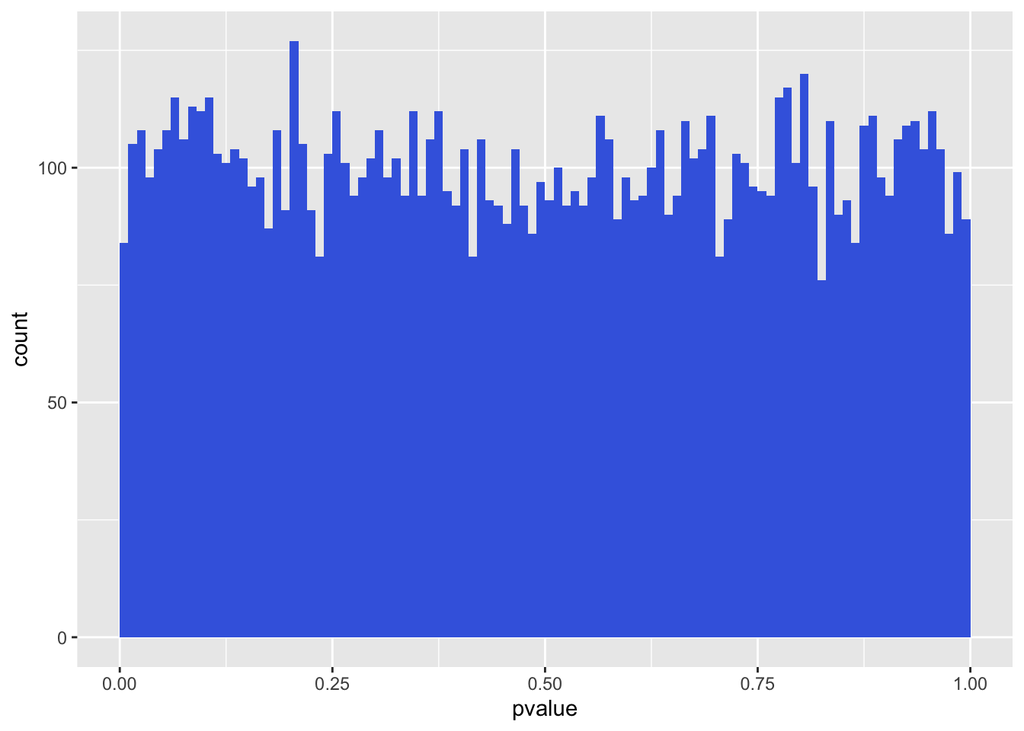

```r
set.seed(0xdada2)
y = cbind(rnorm(10000, 0, 1),
          rnorm(10000, 0, 1),
          rnorm(10000, 0, 1),
          rnorm(10000, 0, 1))
library(genefilter)
pvalue = rowttests(y, factor(c("C","C","T","T")))$p.value
ggplot(tibble(pvalue), aes(x = pvalue)) +
  geom_histogram(binwidth = 0.01, fill = "Royalblue", boundary = 0)
```

Looks good. But now assume that two samples were processed on the same day separately from the others. That day, something happened and the means in both samples were shifted. In that case, the histogram is skewed to the right.

Now try to modify the following code by shifting the mean of the second and fourth sample by two?

```r
# TOOD
#set.seed(0xdada2)
#y = cbind(rnorm(10000, ?, 1),
#          rnorm(10000, ?, 1),
#          rnorm(10000, ?, 1),
#          rnorm(10000, ?, 1))
#pvalue = rowttests(y, factor(c("C","C","T","T")))$p.value
#ggplot(tibble(pvalue), aes(x = pvalue)) +
#  geom_histogram(binwidth = 0.01, fill = "Royalblue", boundary = 0)
```

One way to take such batch effects into account is by adding the batch factor (e.g. the run day) in our model.

What can you do if you suspect there are ``hidden'' factors that affect your data, but they are not documented? (Sometimes, such unknown/undocumented covariates are also called batch effects.) There are methods that try to identify blocking factors in an unsupervised fashion, see e.,g., [Leek and Storey 2007](http://journals.plos.org/plosgenetics/article?id=10.1371/journal.pgen.0030161) or [Stegle et al 2010](http://journals.plos.org/ploscompbiol/article?id=10.1371/journal.pcbi.1000770).

### MA plot

Read the Wikipedia description for [MA plots](https://en.wikipedia.org/wiki/MA_plot). Fold change versus mean of size-factor normalized counts. Logarithmic scaling is used for both axes. By default, points are colored red if the adjusted p-value is less than 0.1. Points which fall out of the y -axis range are plotted as triangles.

To produce the MA plot, we can use the function `plotMA` in the `DESeq2` package.

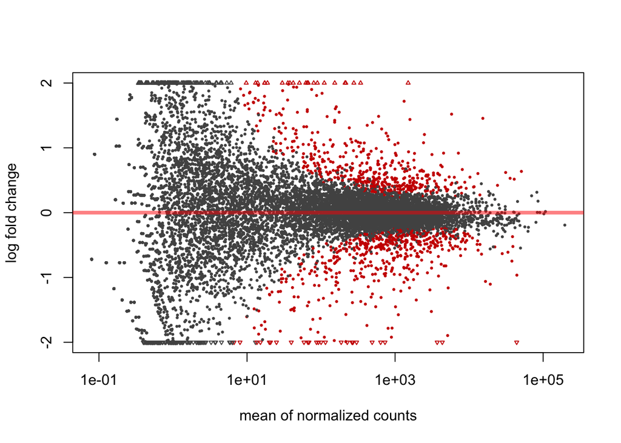

```r
plotMA(pasilla, ylim = c( -2, 2))
```

But as mentioned in class, we can often do better with Empirical Bayes shrinkage of the counts. We can achieve this with a newer method, called "apeglm", as follows:

```r
# Note, to use "apeglm" method you will need the latest version of DESeq2 >= 1.20
# You can update to the development version and install apeglm package using the following commands:
# devtools::install_git("https://git.bioconductor.org/packages/apeglm")
# devtools::install_git("https://git.bioconductor.org/packages/DESeq2")
lfc_shrink_res <- lfcShrink(pasilla, coef="condition_treated_vs_untreated", type="apeglm")
```

```
## using 'apeglm' for LFC shrinkage. If used in published research, please cite:
##     Zhu, A., Ibrahim, J.G., Love, M.I. (2018) Heavy-tailed prior distributions for
##     sequence count data: removing the noise and preserving large differences.
##     Bioinformatics. https://doi.org/10.1093/bioinformatics/bty895
```

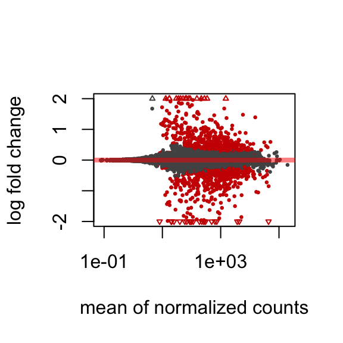

```r
plotMA(lfc_shrink_res, ylim = c( -2, 2))
```

### PCA plot

To produce an ordination plot, we can use the `DESeq2` function `plotPCA` after first transforming the data with the rlog transformation.

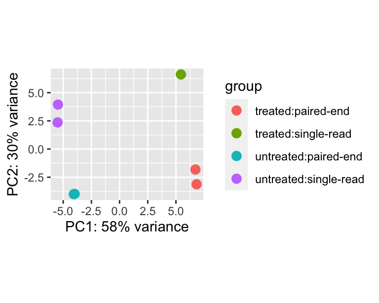

```r
pas_rlog = rlogTransformation(pasilla)
plotPCA(pas_rlog, intgroup=c("condition", "type")) + coord_fixed()
```

This type of plot is useful for visualizing the overall effect of experimental covariates and/or to detect batch effects. Here, the first principal axis, PC1, is mostly aligned with the experimental covariate of interest (untreated / treated), while the second axis is roughly aligned with the sequencing protocol (single-read / paired-end). We used a data transformation, the regularized logarithm or `rlog`. Instead of PCA, other ordination methods, for instance multi-dimensional scaling, can also be useful.

### Heatmaps

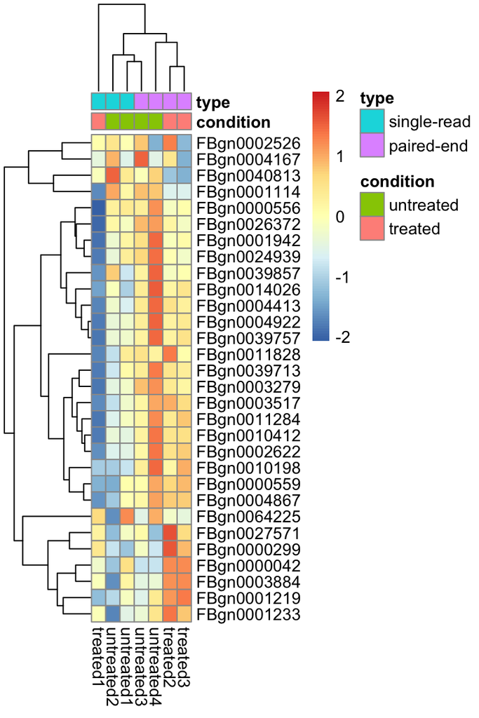

```r
library("pheatmap")
select = order(rowMeans(assay(pas_rlog)), decreasing = TRUE)[1:30]
pheatmap(
  assay(pas_rlog)[select, ],
  scale = "row",
  annotation_col = as.data.frame(colData(pas_rlog)[, c("condition", "type")]))
```

## Two-factor analysis of the pasilla data

Besides the treatment with siRNA, the `pasilla` data have another covariate, `type`, which indicates the type of sequencing that was performed. We saw in the PCA plot that the sequencing `type` had a considerable systematic effect on the data. Our basic analysis did not take this account, but we will do so now. This should help us get a more correct picture of which differences in the data are attributable to the treatment, and which are confounded --or masked-- by the sequencing type.

```r
pasillaTwoFactor = pasilla
design(pasillaTwoFactor) = formula(~ type + condition)
```

```
##   Note: levels of factors in the design contain characters other than
##   letters, numbers, '_' and '.'. It is recommended (but not required) to use
##   only letters, numbers, and delimiters '_' or '.', as these are safe characters
##   for column names in R. [This is a message, not an warning or error]
```

```r
pasillaTwoFactor = DESeq(pasillaTwoFactor)
```

```
## found already estimated dispersions, replacing these
```

```
##   Note: levels of factors in the design contain characters other than
##   letters, numbers, '_' and '.'. It is recommended (but not required) to use
##   only letters, numbers, and delimiters '_' or '.', as these are safe characters
##   for column names in R. [This is a message, not an warning or error]
```

```
##   Note: levels of factors in the design contain characters other than
##   letters, numbers, '_' and '.'. It is recommended (but not required) to use
##   only letters, numbers, and delimiters '_' or '.', as these are safe characters
##   for column names in R. [This is a message, not an warning or error]
```

Of the two variables `type` and `condition`, the one of primary interest is the latter, and in `DESeq2`, the convention is to put it at the end of the formula. This convention has no effect on the model fitting, but it helps simplify some of the subsequent results reporting. Again, we access the results using the `results` function.

```r
res2 = results(pasillaTwoFactor)
head(res2, n = 3)
```

```
## log2 fold change (MLE): condition treated vs untreated
## Wald test p-value: condition treated vs untreated
## DataFrame with 3 rows and 6 columns
##                      baseMean      log2FoldChange             lfcSE
##                     <numeric>           <numeric>         <numeric>
## FBgn0000003 0.171568715207063   0.674551784677737  3.87109094992796
## FBgn0000008  95.1440789963134 -0.0406731386938223 0.222214994845543
## FBgn0000014  1.05657219346166 -0.0849879584016901  2.11182144008079
##                            stat            pvalue              padj
##                       <numeric>         <numeric>         <numeric>
## FBgn0000003   0.174253664768659  0.86166611221445                NA
## FBgn0000008  -0.183035077007712 0.854770496036173 0.951974876389847
## FBgn0000014 -0.0402439130452425 0.967898668421209                NA
```

It is also possible to retrieve the $\log_2$ fold changes, p-values and adjusted p-values associated with the `type` variable. The function `results` takes an argument `contrast` that lets users specify the name of the variable, the level that corresponds to the numerator of the fold change and the level that corresponds to the denominator of the fold change.

```r
resType = results(pasillaTwoFactor,
                  contrast = c("type", "single-read", "paired-end"))
head(resType, n = 3)
```

```
## log2 fold change (MLE): type single-read vs paired-end
## Wald test p-value: type single-read vs paired-end
## DataFrame with 3 rows and 6 columns
##                      baseMean     log2FoldChange             lfcSE
##                     <numeric>          <numeric>         <numeric>
## FBgn0000003 0.171568715207063  -1.61154581772517  3.87108289295889
## FBgn0000008  95.1440789963134 -0.262254705515465 0.220685803638791
## FBgn0000014  1.05657219346166   3.29058556813922  2.08724311747796
##                           stat            pvalue              padj
##                      <numeric>         <numeric>         <numeric>
## FBgn0000003 -0.416303618983828 0.677187844724254                NA
## FBgn0000008  -1.18836237397813 0.234690673499802 0.543821798783573
## FBgn0000014   1.57652241877567  0.11490545630308                NA
```

So what did we gain from this analysis that took into account `type` as a nuisance factor (sometimes also called, more politely, a `blocking factor`), compared to the simple comparison between two groups? Let us plot the p-values from both analyses against each other.

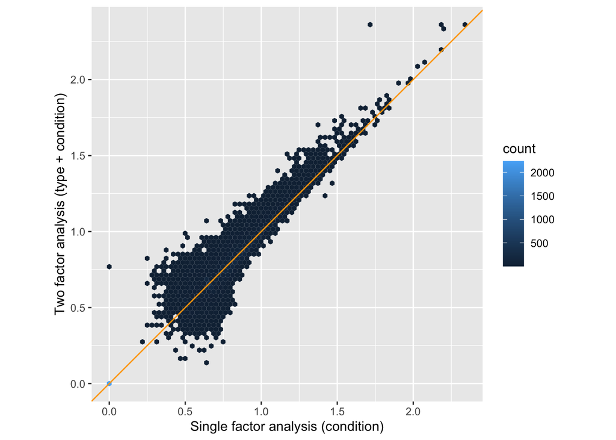

```r
trsf = function(x) ifelse(is.na(x), 0, (-log10(x)) ^ (1/6))
ggplot(tibble(pOne = res$pvalue,
              pTwo = res2$pvalue),
    aes(x = trsf(pOne), y = trsf(pTwo))) +
    geom_hex(bins = 75) + coord_fixed() +
    xlab("Single factor analysis (condition)") +
    ylab("Two factor analysis (type + condition)") +
    geom_abline(col = "orange")
```

Comparison of p-values from the models with a single factor (condition) and with two factors (type + condition). The axes correspond to $(-\log_{10}p)^{\frac{1}{6}}$, an arbitrarily chosen monotonically decreasing transformation that compresses the dynamic range of the p-values for the purpose of visualization. We can see a trend for the joint distribution to lie above the bisector, indicating that the p-values in the two-factor analysis are generally smaller than those in the one-factor analysis.

As we can see, the p-values in the two-factor analysis are similar to those from the one-factor analysis, but are generally smaller. The more sophisticated analysis has led to an, albeit modest, increase in power. We can also see this by counting the number of genes that pass a certain significance threshold in each case:

```r
compareRes = table(
   `simple analysis` = res$padj < 0.1,
   `two factor` = res2$padj < 0.1 )
addmargins( compareRes )
```

```
##                two factor
## simple analysis FALSE TRUE  Sum
##           FALSE  6973  289 7262
##           TRUE     25 1036 1061
##           Sum    6998 1325 8323
```

The two-factor analysis found 1325 genes differentially expressed at an FDR threshold of 10%, while the one-factor analysis found 1061. The two-factor analysis has increased detection power. In general, the gain can be even much larger, or also smaller, depending on the data. The proper choice of the model requires informed adaptation to the experimental design and data quality.

Why do we detect fewer significant genes when we do not take into account the `type` variable? More generally, what does this mean about the benefit of taking into account (or not) blocking factors?

Without modeling the blocking factor, the variability in the data that is due to it has to be absorbed by the $\varepsilon$s. This means that they are generally larger than in the model with the blocking factor. The higher level of noise leads to higher uncertainty in the $\beta$-estimates. On the other hand, the model with the blocking factor has more parameters that need to be estimated. In statistical parlance, the fit has fewer ``degrees of freedom''.  
Both of these effects are counteracting, and which of them prevails, and which of the modeling choices yields more or fewer significant results depends on the data.

As a note of caution: The two p-values calculated above (one with ~condition and one with ~type+condition) correspond to different null hypotheses. This can be a problem when the blocking factor and condition are correlated.